# R Notebook

### Project Elasticsearch-Hadoop

```r
#Library:
suppressMessages(library(plyr))
suppressMessages(library(dplyr))
suppressMessages(library(reshape))
suppressMessages(library(ggplot2))
suppressMessages(library(RNeo4j))
suppressMessages(library(sqldf))
#Csv:
results_frame <- read.csv(file = "/home/r4ph/R/software-history/analysis/results_elastic.csv", stringsAsFactors = FALSE)
#Project
project <- "Elasticsearch-hadoop"
####General Metrics of Individual Projects
data_changes <- filter(results_frame, Project == project)
ggpareto <- function(x, title) {

  #title <- deparse(substitute(x))

  x <- data.frame(modality = na.omit(x))

  Df <- x %>% group_by(modality) %>% summarise(frequency=n()) %>%
    arrange(desc(frequency))

  Df$modality <- ordered(Df$modality, levels = unlist(Df$modality, use.names = F))

  Df <- Df %>% mutate(modality_int = as.integer(modality),
                      cumfreq = cumsum(frequency), cumperc = cumfreq/nrow(x) * 100)

  nr <- nrow(Df)
  N <- sum(Df$frequency)

  Df_ticks <- data.frame(xtick0 = rep(nr +.55, 11), xtick1 = rep(nr +.59, 11),
                         ytick = trunc(seq(0, N, N/10)))

  y2 <- c("  0%", " 10%", " 20%", " 30%", " 40%", " 50%", " 60%", " 70%", " 80%", " 90%", "100%")

  g <- ggplot(Df, aes(x=modality, y=frequency)) +
    geom_bar(stat="identity", aes(fill = modality_int)) +
    geom_line(aes(x=modality_int, y = cumfreq, color = modality_int)) +
    geom_point(aes(x=modality_int, y = cumfreq, color = modality_int), pch = 19) +
    scale_y_continuous(breaks=seq(0, trunc(N), trunc(N/10)), limits=c(trunc(-.02 * N), trunc (N * 1.02))) +
    #scale_y_continuous(trans='log2') +
    scale_x_discrete(breaks = Df$modality) +
    guides(fill = FALSE, color = FALSE) +
    annotate("rect", xmin = nr + .55, xmax = nr + 1,
             ymin = -.02 * N, ymax = N * 1.02, fill = "white") +
    #annotate("text", x = nr + .8, y = seq(0, N/2, N/10), label = y2, size = 3.5) +
    annotate("text", x = nr + .8, y = seq(0, N, N/10), label = y2, size = 3.5) +
    geom_segment(x = nr + .55, xend = nr + .55, y = -.02 * N, yend = N * 1.02, color = "grey50") +
    geom_segment(data = Df_ticks, aes(x = xtick0, y = ytick, xend = xtick1, yend = ytick)) +
    labs(title = paste0("Pareto Chart of ", title), y = "Frequency of Methods With Bugs", x = "Metrics") +
    theme_bw() +
    theme(axis.text.x = element_text(angle = 45, hjust = 1))

  print(g)
}
```

### Raw Dataset:

Aqui é apresentado o dataset que foi discutido na ultima reunião conforme planilha que o Biel gerou no Google Drive. Tal dataset consiste na relação entre os valores de mudanças e inserção de bugs commit. Segue uma descrição das respectivas colunas:

**NoCommits** : A Quantidade de commits (k) que a time serie possui;

**commit** : O respectivo commit dentro da time series com k commits;

**NoTimeSeries** : Quantidade de time series no commit;

**NoBugsIns** : Quantidade de bugs inseridos no respectivo commit;

**noChanges** : Quantidade de mudanças;

**percBugs** : Percentual de bugs inseridos [Formula noBugsIns/sum(noBugsIns)];

**percChanges** : Percentual de mudanças [Formula: noChanges/sum(noChanges) ];

Obs: Ressaltando que os dados no dataset encontram-se desnormalizados, portanto há uma possibilidade de repetição de valores em algumas colunas, ex: na coluna NoTimeSeries, na linha 2 e 3 existe o valor 1681 de maneira repetida, mas no cálculo das respectivas metricas é utilizado somente um valor, visto que existem somente 1681 time series com 2 commits e não o dobro (soma das linhas 2 e 3).

```r
data_changes
```

| X | Project | NoCommits | commit | noTimeSeries | noBugsIns | noChanges | percBugs | percChanges |
| --- | --- | --- | --- | --- | --- | --- | --- | --- |
| 1 | Elasticsearch-hadoop | 1 | 1 | 1082 | 1230 | 30504 | 1.00000000 | 1.000000000 |
| 2 | Elasticsearch-hadoop | 2 | 1 | 1681 | 2466 | 45653 | 0.69133726 | 0.491563748 |
| 3 | Elasticsearch-hadoop | 2 | 2 | 1681 | 1101 | 47220 | 0.30866274 | 0.508436252 |
| 4 | Elasticsearch-hadoop | 3 | 1 | 842 | 1437 | 28041 | 0.52541133 | 0.336966449 |
| 5 | Elasticsearch-hadoop | 3 | 2 | 842 | 751 | 27158 | 0.27458867 | 0.326355509 |
| 6 | Elasticsearch-hadoop | 3 | 3 | 842 | 547 | 28017 | 0.20000000 | 0.336678043 |
| 7 | Elasticsearch-hadoop | 4 | 1 | 410 | 723 | 15412 | 0.44657196 | 0.263475511 |
| 8 | Elasticsearch-hadoop | 4 | 2 | 410 | 324 | 13252 | 0.20012353 | 0.226549278 |
| 9 | Elasticsearch-hadoop | 4 | 3 | 410 | 310 | 13946 | 0.19147622 | 0.238413540 |
| 10 | Elasticsearch-hadoop | 4 | 4 | 410 | 262 | 15885 | 0.16182829 | 0.271561672 |

[output cut: 268 more lines]

### Final Dataset:

Aqui é apresentado o dataset com as metricas calculadas com o objetivo de gerar os respectivos gráficos presentes na Goal 1 e 2. Segue uma descrição das colunas e suas respectivas formulas:

**NoCommits** : A Quantidade de commits (k) que a time serie possui;

**NoTimeSeries** : Quantidade de time series no commit;

**noChanges** : Quantidade de mudanças;

**NoBugsIns** : Quantidade de bugs inseridos no respectivo commit;

**BugsByTs** : Quantidade de bugs por time series [Formula : sum(noBugsIns)/max(noTimeSeries) ];

**ChangesByTs**: Quantidade de mudanças pro time series [Formula: sum(noChanges)/ max(noTimeSeries)];

**PercBugsByTs**: Percentual de bugs por time series [Formula: (BugsByTs/sum(BugsByTs)) * 100];

**PercBugsByCommit**: Percentual de Bugs por commits [Formula: (noBugsIns/sum(noBugsIns)) * 100];

**PercBugsByChanges**: Percentual de Bugs por mudanças [Formula: (BugsByChanges/sum(BugsByChanges)) * 100];

**PercTs**: Percentual de time series [Formula: noTimeSeries / sum(noTimeSeries)) * 100];

**PercChangesByTs**: Percentual de mudanças por time series [Formula: (ChangesByTs / sum(ChangesByTs)) * 100];

**PercChanges**: Percentual de mudanças [Formula: (noChanges / sum(noChanges)) * 100];

Obs: Conforme explicado, os dados anteriores (raw dataset) tem algumas colunas desnormalizadas (NoTimeSeries), portanto algumas formulas contém o valor maximo da respectiva coluna dentro do agrupamento definido.

```r
data_plot <- data_changes %>%
    dplyr::group_by(Project, NoCommits) %>%
    dplyr::summarise(noTimeSeries = max(noTimeSeries),
                    noChanges = sum(noChanges),
                    noBugsIns = sum(noBugsIns),
                    BugsByTs = sum(noBugsIns)/max(noTimeSeries),
                    BugsByChanges = sum(noBugsIns)/ sum(noChanges),
                    ChangesByTs = sum(noChanges)/ max(noTimeSeries)) %>%
    dplyr::mutate(PercBugsByTs = (BugsByTs/sum(BugsByTs)) * 100,
                  PercBugsByCommit = (noBugsIns/sum(noBugsIns)) * 100,
                  PercBugsByChanges = (BugsByChanges/sum(BugsByChanges)) * 100,
                  PercTs = (noTimeSeries / sum(noTimeSeries)) * 100,
                  PercChangesByTs = (ChangesByTs / sum(ChangesByTs)) * 100,
                  PercChanges = (noChanges / sum(noChanges)) * 100) %>%
    dplyr::ungroup()
data_plot
```

| Project | NoCommits | noTimeSeries | noChanges | noBugsIns | BugsByTs | BugsByChanges | ChangesByTs | PercBugsByTs | PercBugsByCommit | PercBugsByChanges | PercTs | PercChangesByTs | PercChanges |
| --- | --- | --- | --- | --- | --- | --- | --- | --- | --- | --- | --- | --- | --- |
| Elasticsearch-hadoop | 1 | 1082 | 30504 | 1230 | 1.136784 | 0.04032258 | 28.19224 | 0.4228732 | 9.3600183 | 7.448212 | 23.31896552 | 0.1996169 | 6.9030442 |
| Elasticsearch-hadoop | 2 | 1681 | 92873 | 3567 | 2.121951 | 0.03840729 | 55.24866 | 0.7893466 | 27.1440530 | 7.094428 | 36.22844828 | 0.3911916 | 21.0171264 |
| Elasticsearch-hadoop | 3 | 842 | 83216 | 2735 | 3.248219 | 0.03286628 | 98.83135 | 1.2083078 | 20.8127235 | 6.070916 | 18.14655172 | 0.6997816 | 18.8317507 |
| Elasticsearch-hadoop | 4 | 410 | 58495 | 1619 | 3.948780 | 0.02767758 | 142.67073 | 1.4689104 | 12.3202192 | 5.112483 | 8.83620690 | 1.0101891 | 13.2373974 |
| Elasticsearch-hadoop | 5 | 217 | 40622 | 935 | 4.308756 | 0.02301708 | 187.19816 | 1.6028180 | 7.1151358 | 4.251616 | 4.67672414 | 1.3254683 | 9.1927439 |
| Elasticsearch-hadoop | 6 | 147 | 35268 | 787 | 5.353741 | 0.02231485 | 239.91837 | 1.9915432 | 5.9888897 | 4.121902 | 3.16810345 | 1.6987571 | 7.9811357 |
| Elasticsearch-hadoop | 7 | 92 | 20749 | 562 | 6.108696 | 0.02708564 | 225.53261 | 2.2723792 | 4.2766913 | 5.003143 | 1.98275862 | 1.5968978 | 4.6954912 |
| Elasticsearch-hadoop | 8 | 60 | 19345 | 427 | 7.116667 | 0.02207289 | 322.41667 | 2.6473353 | 3.2493722 | 4.077208 | 1.29310345 | 2.2828915 | 4.3777665 |
| Elasticsearch-hadoop | 9 | 40 | 15212 | 349 | 8.725000 | 0.02294241 | 380.30000 | 3.2456207 | 2.6558101 | 4.237823 | 0.86206897 | 2.6927381 | 3.4424701 |
| Elasticsearch-hadoop | 10 | 17 | 8551 | 166 | 9.764706 | 0.01941293 | 503.00000 | 3.6323818 | 1.2632220 | 3.585873 | 0.36637931 | 3.5615232 | 1.9350882 |

[output cut: 13 more lines]

### (G1)To investigate the occurrence of commits along the history;

#### (Q1.1) How often are commits performed?

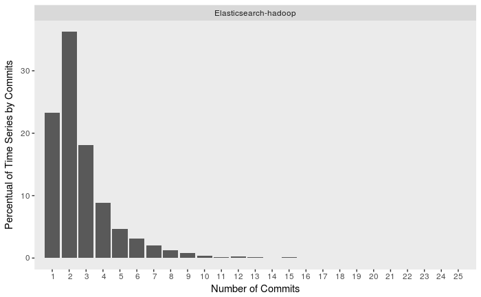

```r
plot1 <- ggplot(data_plot) +
  geom_bar(aes(x=NoCommits,y=PercTs,group=Project), position = "dodge", stat = "identity")+
  facet_grid(.~Project,scales="free") +
  theme(legend.position= c(0.7, 0.95), legend.direction="horizontal", legend.title = element_blank(),
        legend.text=element_text(size=5), legend.background = element_rect(fill = "transparent", colour = NA) ) +
  ylab("Percentual of Time Series by Commits") + scale_x_discrete(name ="Number of Commits", limits=seq(1,25)) +
  theme(panel.grid.minor = element_blank(),
        panel.grid.major = element_blank(),
        plot.background = element_rect(fill = "transparent", colour = NA))
plot1
```

#### (Q1.2) How disperse are changes among time series? (Changes x Commits)

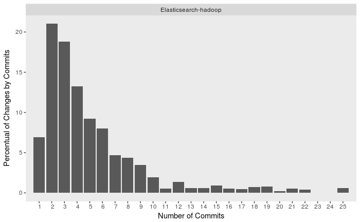

```r
  plot2 <- ggplot(data_plot) +
  geom_bar(aes(x=NoCommits,y=PercChanges), position = "dodge", stat = "identity")+
  facet_grid(.~Project,scales="free") +
  theme(legend.position= c(0.7, 0.95), legend.direction="horizontal", legend.title = element_blank(),
        legend.text=element_text(size=5), legend.background = element_rect(fill = "transparent", colour = NA)) +
  ylab("Percentual of Changes by Commits") + scale_x_discrete(name ="Number of Commits", limits=seq(1,25)) +
  theme(panel.grid.minor = element_blank(),
        panel.grid.major = element_blank(),
        plot.background = element_rect(fill = "transparent", colour = NA))
plot2
```

#### (Q1.3) How disperse are changes among commits? (Changes x Time Series)

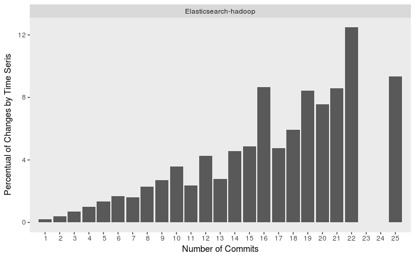

```r
  plot2 <- ggplot(data_plot) +
  geom_bar(aes(x=NoCommits,y=PercChangesByTs), position = "dodge", stat = "identity")+
  facet_grid(.~Project,scales="free") +
  theme(legend.position= c(0.7, 0.95), legend.direction="horizontal", legend.title = element_blank(),
        legend.text=element_text(size=5), legend.background = element_rect(fill = "transparent", colour = NA)) +
  ylab("Percentual of Changes by Time Seris") + scale_x_discrete(name ="Number of Commits", limits=seq(1,25)) +
  theme(panel.grid.minor = element_blank(),
        panel.grid.major = element_blank(),
        plot.background = element_rect(fill = "transparent", colour = NA))
plot2
```

### (G2)To assess the introduction of bugs along the history;

#### (Q2.1) How often are bugs introduced among the time series? (Bugs x Time Series)

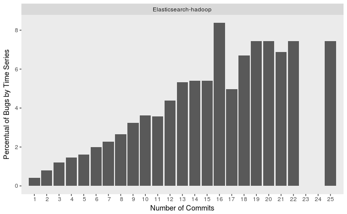

```r
  plot2 <- ggplot(data_plot) +
  geom_bar(aes(x=NoCommits,y=PercBugsByTs), position = "dodge", stat = "identity")+
  facet_grid(.~Project,scales="free") +
  theme(legend.position= c(0.7, 0.95), legend.direction="horizontal", legend.title = element_blank(),
        legend.text=element_text(size=5), legend.background = element_rect(fill = "transparent", colour = NA)) +
  ylab("Percentual of Bugs by Time Series") + scale_x_discrete(name ="Number of Commits", limits=seq(1,25)) +
  theme(panel.grid.minor = element_blank(),
        panel.grid.major = element_blank(),
        plot.background = element_rect(fill = "transparent", colour = NA))
plot2
```

#### (Q2.2) How often are bugs introduced among the commits? (Bugs x Commits)

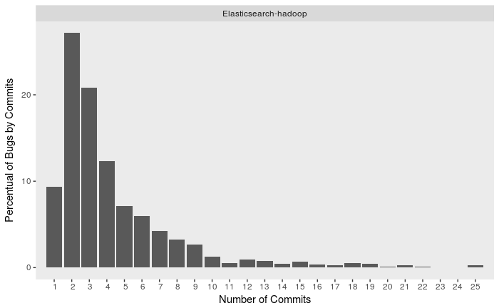

```r
  plot2 <- ggplot(data_plot) +
  geom_bar(aes(x=NoCommits,y=PercBugsByCommit), position = "dodge", stat = "identity")+
  facet_grid(.~Project,scales="free") +
  theme(legend.position= c(0.7, 0.95), legend.direction="horizontal", legend.title = element_blank(),
        legend.text=element_text(size=5), legend.background = element_rect(fill = "transparent", colour = NA)) +
  ylab("Percentual of Bugs by Commits") + scale_x_discrete(name ="Number of Commits", limits=seq(1,25)) +
  theme(panel.grid.minor = element_blank(),
        panel.grid.major = element_blank(),
        plot.background = element_rect(fill = "transparent", colour = NA))
plot2
```

#### (Q2.3) How often are bugs introduced among the changes? (Bugs x CHanges)

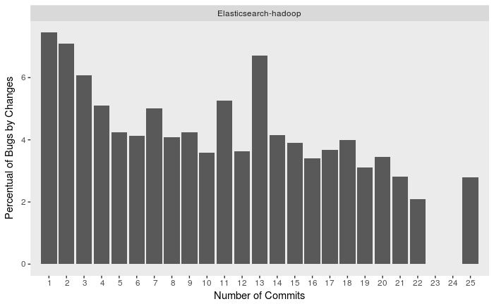

```r
  plot2 <- ggplot(data_plot) +
  geom_bar(aes(x=NoCommits,y=PercBugsByChanges), position = "dodge", stat = "identity")+
  facet_grid(.~Project,scales="free") +
  theme(legend.position= c(0.7, 0.95), legend.direction="horizontal", legend.title = element_blank(),
        legend.text=element_text(size=5), legend.background = element_rect(fill = "transparent", colour = NA)) +
  ylab("Percentual of Bugs by Changes") + scale_x_discrete(name ="Number of Commits", limits=seq(1,25)) +
  theme(panel.grid.minor = element_blank(),
        panel.grid.major = element_blank(),
        plot.background = element_rect(fill = "transparent", colour = NA))
plot2
```

### (G3) To analyse the kind of changes are mostly related to the bugs insertion;

#### (Q3.1) Which are the types of changes more frequent in the history of of bugs insertion?

```r
methods_insertions <-
  read.csv(
    "~/R/analysis/insertions/insertionsall.csv",
    stringsAsFactors = FALSE
  )
```

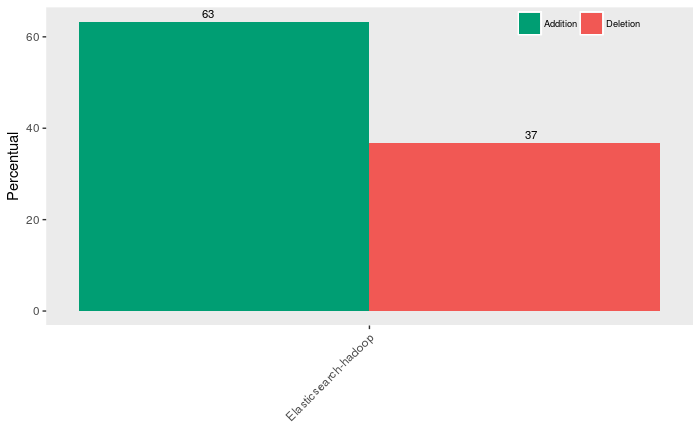

```r
#Changes Chart
methods_changes <- filter(methods_insertions, changeType != 'All', groupMetric == 'All', Metric == 'All', Project == project)
methods_changes[methods_changes$changeType == "changeMetricsAddition", c("changeType")] <- "Addition"
methods_changes[methods_changes$changeType == "changeMetricsDeletion", c("changeType")] <- "Deletion"
cbPalette <- c("#009E73", "#F15854")
methods_changes <-  as.data.frame(
  methods_changes %>%
    dplyr::group_by(Project, changeType) %>%
    dplyr::summarise(totalChanges = sum(Count)) %>%
    mutate(Percentual = totalChanges / sum(totalChanges) * 100) %>%
    ungroup()
)
ggplot(methods_changes) +
  geom_bar(aes(x = Project, y = Percentual, fill = changeType, group = changeType), position = "dodge", stat = "identity") +
  geom_text( aes(x = Project, y = Percentual, label = round(Percentual), group = changeType),
             check_overlap = TRUE, position = position_dodge(width = 1), vjust = -0.5, size = 3) + #scale_fill_grey() +
  theme(axis.text.x = element_text(angle = 45, hjust = 1)) +
  theme(legend.position= c(0.82, 0.95), legend.direction="horizontal", legend.title = element_blank(),
        axis.title.x=element_blank(), legend.text=element_text(size=7), legend.background = element_rect(fill = "transparent", colour = NA) ) +
  theme(panel.grid.minor = element_blank(),
        panel.grid.major = element_blank(),
        plot.background = element_rect(fill = "transparent", colour = NA)) +
  scale_fill_manual(values=cbPalette)
```

#### (Q3.2) Individual Pareto

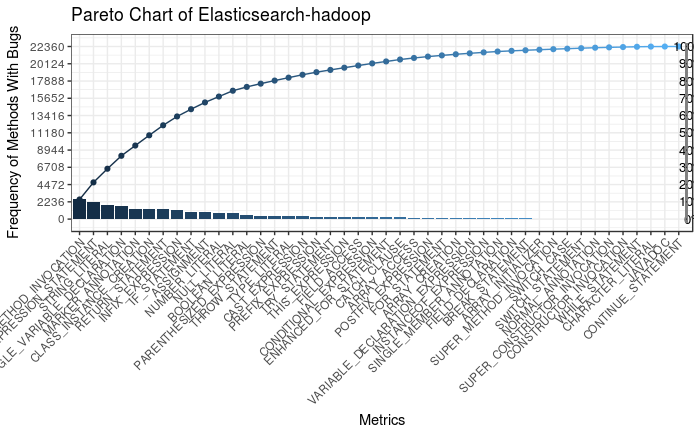

```r
colMethods <- c("Project", "MethodName", "Metric", "groupMetric", "changeType", "elementsValue", "NtimeofCommits", "Count")
#Filter:D
methods_ind <- filter(methods_insertions, groupMetric != "RM", changeType == 'All', groupMetric != 'All', Metric != 'All', Project == project)
#resultsClasses <- subset( resultsClasses, select = c(colClasses) )
methods_ind <- subset( methods_ind, select = c(colMethods))
methods_ind <-  as.data.frame(
  methods_ind %>%
    dplyr::group_by(Project, Metric) %>%
    dplyr::summarise(totalChanges = sum(Count))
)
metrics <- c()
# Applying the function to the pareto function:
df <- filter(methods_ind)[,c(2,3)]
i<-1
for (x in 1:nrow(df)){
  for (y in 1:df$totalChanges[x]){
    metrics[i] <- df$Metric[x]
    i <- i + 1
  }
}
ggpareto(metrics, project)
```

#### (Q3.3) Groups Pareto

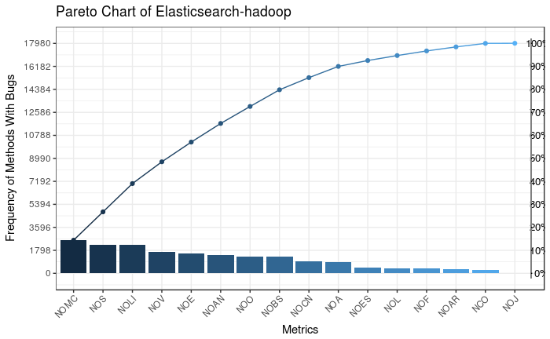

```r
#Methods Groups
#Filter:D
methods_groups<- filter(methods_insertions, groupMetric != "RM", changeType == 'All', groupMetric != 'All', Metric == 'All',Project == project)
methods_groups <-  as.data.frame(
  methods_groups %>%
  dplyr::group_by(Project, groupMetric) %>%
  dplyr::summarise(totalChanges = sum(Count))
  )
metrics <- c()
# Applying the function to the pareto function:
df <- filter(methods_groups, Project == project)[,c(2,3)]
i<-1
for (x in 1:nrow(df)){
  for (y in 1:df$totalChanges[x]){
    metrics[i] <- df$groupMetric[x]
    i <- i + 1
  }
}
ggpareto(metrics, project)
```

### (G4) To analyse the relation between the history of changes and bugs;

#### (Q4.1) Is a high number of changes an indicative of bugs introduction?

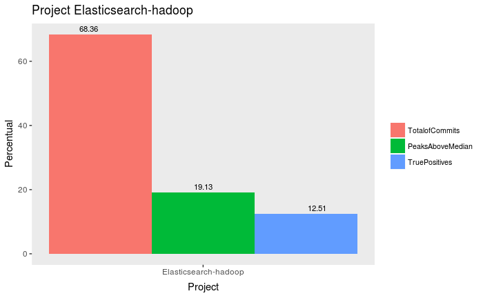

```r
#Changes Chart
methods_changes <- filter(methods, changeType != 'All', groupMetric == 'All', Metric == 'All'
                          ,Project == project)
#Calculing peaks
methods_changes <- genId(methods_changes)
listofPeaks <<- methods_changes$elementsValue
listofBugs <<- methods_changes$bugsValue
methods_changes[,c("peaksMedian", "tp", "fp", "fn", "tn")] <- 0
methods_changes[,c("peaksMedian", "tp", "fp", "fn", "tn")] <-  plyr::ldply(methods_changes$id, getStatsProcess)
dfPeaks <- as.data.frame(
  methods_changes %>%
    dplyr::group_by(Project) %>%
    dplyr::summarise(
      TotalofCommits = sum(NtimeofCommits),
      PeaksAboveMedian = sum(peaksMedian),
      TruePositives = sum(tp)
#      fp = sum(fp),
#      fn = sum(fn),
#      tn = sum(tn)
    )
)
tdfPeaks <- melt(dfPeaks, id = (c("Project")))
colnames(tdfPeaks) <- c("Project", "Peaks", "Values")
#Summarize the type of methods by percentual
dfPeaksProjects <- tdfPeaks %>%
  dplyr::group_by(Project, Peaks) %>%
  dplyr::summarise(Values = sum(Values)) %>%
  dplyr::mutate(Percentual = Values / sum(Values) * 100) %>%
  dplyr::ungroup()
#Plot
ggplot(dfPeaksProjects) +
  geom_bar(aes(x = Project, y = Percentual, fill = Peaks, group = Peaks), position = "dodge", stat = "identity") +
  geom_text(aes(x = Project, y = Percentual, label = round(Percentual,2), group = Peaks),
            check_overlap = TRUE, position = position_dodge(width = 1), vjust = -0.5, size = 3) +
  theme(legend.direction="vertical", legend.title = element_blank(), legend.text=element_text(size=8),
        legend.background = element_rect(fill = "transparent", colour = NA), axis.ticks.x = ) +
  theme(panel.grid.minor = element_blank(),
        panel.grid.major = element_blank(),
        plot.background = element_rect(fill = "transparent", colour = NA)) +
  ggtitle(paste0("Project ", project)) + ylab("Percentual")
```

A coluna vermelha (Total of commits) representa os commits que não estão acima do pico, a verde (PeaksaboveMedian) são os comits que ficaram acima da mediana e coluna azul são os TP’s, ou seja, aqueles commits que estão acima da mediana (threshold) e possuem um bug presente.

#### (Q4.2) Which kind of changes are better indicative of bugs introduction?

** Essa question seriam as mudanças acima por nívels? Ex: calcular os tps dos níveis de add/del, grupos e metricas individuais? **

#### (Q4.3) How relate are changes to the bugs introduction? (Granger Positives)

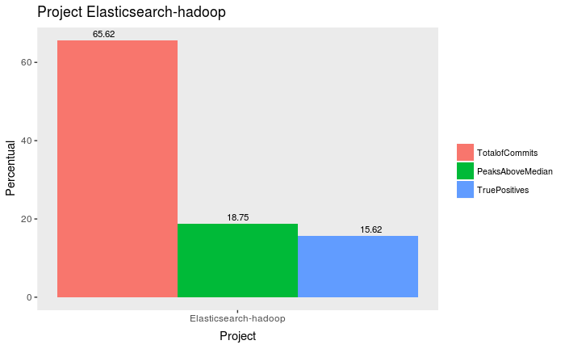

```r
#Changes Chart
methods_changes <- filter(methods, changeType != 'All', groupMetric == 'All', Metric == 'All'
                          ,Project == project, Granger == 1,
                          P1 == 1, P2 ==1, P3 ==1, P4 ==1,P5 ==1)
#Calculing peaks
methods_changes <- genId(methods_changes)
listofPeaks <<- methods_changes$elementsValue
listofBugs <<- methods_changes$bugsValue
methods_changes[,c("peaksMedian", "tp", "fp", "fn", "tn")] <- 0
methods_changes[,c("peaksMedian", "tp", "fp", "fn", "tn")] <-  plyr::ldply(methods_changes$id, getStatsProcess)
dfPeaks <- as.data.frame(
  methods_changes %>%
    dplyr::group_by(Project) %>%
    dplyr::summarise(
      TotalofCommits = sum(NtimeofCommits),
      PeaksAboveMedian = sum(peaksMedian),
      TruePositives = sum(tp)
#      fp = sum(fp),
#      fn = sum(fn),
#      tn = sum(tn)
    )
)
tdfPeaks <- melt(dfPeaks, id = (c("Project")))
colnames(tdfPeaks) <- c("Project", "Peaks", "Values")
#Summarize the type of methods by percentual
dfPeaksProjects <- tdfPeaks %>%
  dplyr::group_by(Project, Peaks) %>%
  dplyr::summarise(Values = sum(Values)) %>%
  dplyr::mutate(Percentual = Values / sum(Values) * 100) %>%
  dplyr::ungroup()
#Plot
ggplot(dfPeaksProjects) +
  geom_bar(aes(x = Project, y = Percentual, fill = Peaks, group = Peaks), position = "dodge", stat = "identity") +
  geom_text(aes(x = Project, y = Percentual, label = round(Percentual,2), group = Peaks),
            check_overlap = TRUE, position = position_dodge(width = 1), vjust = -0.5, size = 3) +
  theme(legend.direction="vertical", legend.title = element_blank(), legend.text=element_text(size=8),
        legend.background = element_rect(fill = "transparent", colour = NA), axis.ticks.x = ) +
  theme(panel.grid.minor = element_blank(),
        panel.grid.major = element_blank(),
        plot.background = element_rect(fill = "transparent", colour = NA)) +
  ggtitle(paste0("Project ", project)) + ylab("Percentual")
```